### Bilingual milestones in early language development

#### A part of the project: StarWords: a study of parental report on words

##### Pre-registraiton #1, see https://osf.io/pzykv

### Participants

Below data from children who  
- match recruitment criteria (according to pre-registration) plus children bilingual with Polish and other language (meeting recruitment criteria).  
- do not have any health problems (following pre-registration criteria).  
- are matched one-to-one.

*Note 1. This is how many children meet the criteria, but later we’ll see how much data from them we actually have.*

#### Checking whether the match was succesfull

We’re checking whether the groups differ on matching variables: age on study entry, parental education, gender and length of parental reporting. The matching was done one to one - for each bilingual child we found a similiar monolingual child in the data set.  
Note: Since we lacked parental edu information for many children (671 monolinguals and 179 bilinguals), I included a dummy level of parental education “0” (meaning: no data available); as a result, out of 302 pairs, 179 were matched on missing information (level “0”), and the remaining children were matched on the reported parental education level (six levels: PhD, higher education, unfinished higher education, vocational, secondary and primary education). This was the only way I could think of to match the children with some info, but at the same time not exclude children with no information from the match (and analyses).

### Table 1 and A1

|  | Bilinguals | Monolinguals1 | Monolinguals2 |
| --- | --- | --- | --- |
| CHILD_FEMALE | 155 | 155 | 155 |
| CHILD_MALE | 147 | 147 | 147 |

|  | Bilinguals | Monolinguals1 | Monolinguals2 |
| --- | --- | --- | --- |
| PHD | 8 | 6 | 3 |
| HIGHER_EDU | 88 | 94 | 99 |
| UNFINISHED_HIGHER_EDU | 15 | 11 | 10 |
| TECHNICAL | 4 | 2 | 1 |
| SECONDARY | 7 | 8 | 9 |
| PRIMARY | 1 | NA | NA |
| NA | 179 | 181 | 180 |

### Our research questions

1. RQ1: Will bilinguals reach particular motor and language milestones at a similar time as their Polish monolingual peers, **at least in one of their languages**?
2. RQ2: Will bilinguals reach particular language milestones at a similar time **in both their languages, L1 and L2**?
3. RQ3: In bilinguals, is language-specific (L1/L2) mean **input quantity** before reaching a milestone linked to the age of reaching that milestone (in L1/L2)?
4. RQ4: In bilinguals, is language-specific (L1/L2) **input quality** linked to the age of reaching language milestones (in L1/L2)?

### RQ1: Bilinguals vs. monolinguals

These analyses include the bilingual group (n = 302) and one monolingual group, from the first match (n = 302). In the Supplementary Materials below you’ll find the comparisons between the bilingual group and the two monolingual groups.

*Note 1.* For motor milestones and babbling: ‘How old was your child when they started….’  
*Note 2.* For words and utterances milestones: The number of words reported by the parent in the app.  
*Note 3.* We count all bilinguals’ words together (e.g. Polish + English).

#### Table 3 - descriptive stats

| milestone | group | n | Age (M) | Age (SD) |
| --- | --- | --- | --- | --- |
| crawling | Bilinguals | 77 | 7.88 | 1.79 |
| crawling | Monolinguals | 74 | 8.00 | 1.95 |
| babbling | Bilinguals | 58 | 7.31 | 2.64 |
| babbling | Monolinguals | 54 | 6.76 | 1.80 |
| walking | Bilinguals | 49 | 12.16 | 1.59 |
| walking | Monolinguals | 43 | 12.67 | 2.24 |
| w1 | Bilinguals | 140 | 14.92 | 5.53 |
| w1 | Monolinguals | 137 | 15.22 | 5.13 |
| w10 | Bilinguals | 50 | 16.82 | 4.34 |
| w10 | Monolinguals | 47 | 16.83 | 3.75 |
| w50 | Bilinguals | 15 | 18.60 | 3.72 |
| w50 | Monolinguals | 14 | 20.00 | 1.92 |
| m1 | Bilinguals | 34 | 19.21 | 3.62 |
| m1 | Monolinguals | 41 | 19.29 | 3.72 |
| m3 | Bilinguals | 14 | 20.36 | 3.03 |
| m3 | Monolinguals | 18 | 21.44 | 1.98 |
| m4 | Bilinguals | 3 | 17.67 | 0.58 |
| m4 | Monolinguals | 6 | 22.83 | 1.94 |

#### Figure 1

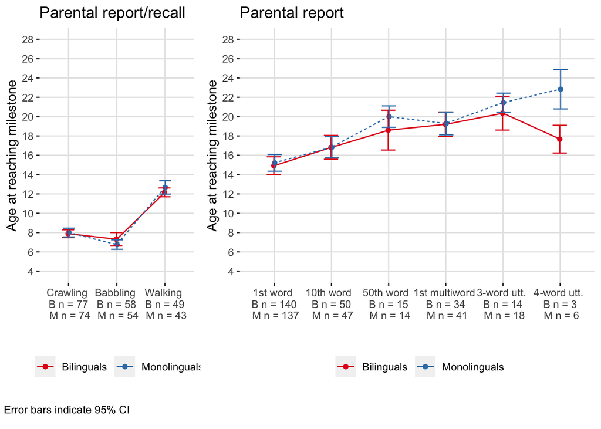

#### RQ1: t-tests

| milestone | estimate | estimate1 | estimate2 | .y. | group1 | group2 | n1 | n2 | statistic | p | df | conf.low | conf.high | method | alternative | p.adj | p.adj.signif |
| --- | --- | --- | --- | --- | --- | --- | --- | --- | --- | --- | --- | --- | --- | --- | --- | --- | --- |
| crawling | -0.12 | 7.9 | 8.0 | age_at_element | Bilinguals | Monolinguals | 77 | 74 | -0.38 | 0.70 | 147 | -0.72 | 0.49 | T-test | two.sided | 1 | ns |
| babbling | 0.55 | 7.3 | 6.8 | age_at_element | Bilinguals | Monolinguals | 58 | 54 | 1.30 | 0.20 | 101 | -0.29 | 1.39 | T-test | two.sided | 1 | ns |
| walking | -0.51 | 12.2 | 12.7 | age_at_element | Bilinguals | Monolinguals | 49 | 43 | -1.25 | 0.22 | 74 | -1.33 | 0.31 | T-test | two.sided | 1 | ns |
| w1 | -0.30 | 14.9 | 15.2 | age_at_element | Bilinguals | Monolinguals | 140 | 137 | -0.46 | 0.64 | 274 | -1.56 | 0.96 | T-test | two.sided | 1 | ns |
| w10 | -0.01 | 16.8 | 16.8 | age_at_element | Bilinguals | Monolinguals | 50 | 47 | -0.01 | 0.99 | 94 | -1.64 | 1.62 | T-test | two.sided | 1 | ns |
| w50 | -1.40 | 18.6 | 20.0 | age_at_element | Bilinguals | Monolinguals | 15 | 14 | -1.29 | 0.21 | 21 | -3.66 | 0.86 | T-test | two.sided | 1 | ns |
| m1 | -0.09 | 19.2 | 19.3 | age_at_element | Bilinguals | Monolinguals | 34 | 41 | -0.10 | 0.92 | 71 | -1.78 | 1.61 | T-test | two.sided | 1 | ns |
| m3 | -1.09 | 20.4 | 21.4 | age_at_element | Bilinguals | Monolinguals | 14 | 18 | -1.16 | 0.26 | 21 | -3.03 | 0.85 | T-test | two.sided | 1 | ns |

#### RQ1: Bayes Factor

```r
# Following Hoijtink, H., Mulder, J., Van Lissa, C., & Gu, X. (2019). A tutorial on testing hypotheses using the Bayes factor. Psychological Methods, 24(5), 539–556. https://doi.org/10.1037/met0000201

citation("bain")
```

```
##
##
##   Gu X, Hoijtink H, Mulder J, van Lissa CJ (2023). _bain: Bayes Factors
##   for Informative Hypotheses_. R package version 0.2.10,
##   <https://CRAN.R-project.org/package=bain>.
##
## A BibTeX entry for LaTeX users is
##
##   @Manual{,
##     title = {bain: Bayes Factors for Informative Hypotheses},
##     author = {Xin Gu and Herbert Hoijtink and Joris Mulder and Caspar J {van Lissa}},
##     year = {2023},
##     note = {R package version 0.2.10},
##     url = {https://CRAN.R-project.org/package=bain},
##   }
```

#### Crawling

```r
# crawling

bf_rq1 <- lineplot_rq1 %>%
  filter(group == "Bilinguals" | group == "Monolinguals")

prepbf <- bain::t_test(bf_rq1$crawling ~ bf_rq1$group, var.equal = T)

set.seed(100)
resbf<-bain(prepbf,"groupBilinguals = groupMonolinguals")
resbf
```

```
## Bayesian informative hypothesis testing for an object of class t_test:
##
##    Fit   Com   BF.u   BF.c   PMPa  PMPb  PMPc
## H1 1.225 0.099 12.325 12.325 1.000 0.925 0.925
## Hu                                 0.075
## Hc                                       0.075
##
## Hypotheses:
##   H1: groupBilinguals=groupMonolinguals
##
## Note: BF.u denotes the Bayes factor of the hypothesis at hand versus the unconstrained hypothesis Hu. BF.c denotes the Bayes factor of the hypothesis at hand versus its complement. PMPa contains the posterior model probabilities of the hypotheses specified. PMPb adds Hu, the unconstrained hypothe…
```

```r
summary(resbf, ci=0.95)
```

[output not shown]

```r
# Sensitivity Analysis
# compute BF01 using b-g (same BF as printed above)
set.seed(100)
resbf_sa<-bain(prepbf,"groupBilinguals = groupMonolinguals", fraction = 1)
print(resbf_sa)
```

```
## Bayesian informative hypothesis testing for an object of class t_test:
##
##    Fit   Com   BF.u   BF.c   PMPa  PMPb  PMPc
## H1 1.225 0.099 12.325 12.325 1.000 0.925 0.925
## Hu                                 0.075
## Hc                                       0.075
##
## Hypotheses:
##   H1: groupBilinguals=groupMonolinguals
##
## Note: BF.u denotes the Bayes factor of the hypothesis at hand versus the unconstrained hypothesis Hu. BF.c denotes the Bayes factor of the hypothesis at hand versus its complement. PMPa contains the posterior model probabilities of the hypotheses specified. PMPb adds Hu, the unconstrained hypothe…
```

```r
# compute BF01 replacing b-g by 2 x b-g
# setting fraction to 2 implies using 2 x b-g
set.seed(100)
resbf_sa<-bain(prepbf,"groupBilinguals = groupMonolinguals", fraction = 2)
print(resbf_sa)
```

```
## Bayesian informative hypothesis testing for an object of class t_test:
##
##    Fit   Com   BF.u  BF.c  PMPa  PMPb  PMPc
## H1 1.225 0.141 8.715 8.715 1.000 0.897 0.897
## Hu                               0.103
## Hc                                     0.103
##
## Hypotheses:
##   H1: groupBilinguals=groupMonolinguals
##
## Note: BF.u denotes the Bayes factor of the hypothesis at hand versus the unconstrained hypothesis Hu. BF.c denotes the Bayes factor of the hypothesis at hand versus its complement. PMPa contains the posterior model probabilities of the hypotheses specified. PMPb adds Hu, the unconstrained hypothe…
```

```r
# compute BF01 replacing b-g by 3 x b-g
set.seed(100)
resbf_sa<-bain(prepbf,"groupBilinguals = groupMonolinguals", fraction = 3)
print(resbf_sa)
```

```
## Bayesian informative hypothesis testing for an object of class t_test:
##
##    Fit   Com   BF.u  BF.c  PMPa  PMPb  PMPc
## H1 1.225 0.172 7.116 7.116 1.000 0.877 0.877
## Hu                               0.123
## Hc                                     0.123
##
## Hypotheses:
##   H1: groupBilinguals=groupMonolinguals
##
## Note: BF.u denotes the Bayes factor of the hypothesis at hand versus the unconstrained hypothesis Hu. BF.c denotes the Bayes factor of the hypothesis at hand versus its complement. PMPa contains the posterior model probabilities of the hypotheses specified. PMPb adds Hu, the unconstrained hypothe…
```

#### Babbling

```r
# babbling
prepbf <- bain::t_test(bf_rq1$babbling ~ bf_rq1$group, var.equal = T)
set.seed(100)
resbf<-bain(prepbf,"groupBilinguals = groupMonolinguals")
resbf
```

```
## Bayesian informative hypothesis testing for an object of class t_test:
##
##    Fit   Com   BF.u  BF.c  PMPa  PMPb  PMPc
## H1 0.504 0.068 7.433 7.433 1.000 0.881 0.881
## Hu                               0.119
## Hc                                     0.119
##
## Hypotheses:
##   H1: groupBilinguals=groupMonolinguals
##
## Note: BF.u denotes the Bayes factor of the hypothesis at hand versus the unconstrained hypothesis Hu. BF.c denotes the Bayes factor of the hypothesis at hand versus its complement. PMPa contains the posterior model probabilities of the hypotheses specified. PMPb adds Hu, the unconstrained hypothe…
```

```r
# Sensitivity Analysis
# compute BF01 using b-g (same BF as printed above)
set.seed(100)
resbf_sa<-bain(prepbf,"groupBilinguals = groupMonolinguals", fraction = 1)
print(resbf_sa)
```

```
## Bayesian informative hypothesis testing for an object of class t_test:
##
##    Fit   Com   BF.u  BF.c  PMPa  PMPb  PMPc
## H1 0.504 0.068 7.433 7.433 1.000 0.881 0.881
## Hu                               0.119
## Hc                                     0.119
##
## Hypotheses:
##   H1: groupBilinguals=groupMonolinguals
##
## Note: BF.u denotes the Bayes factor of the hypothesis at hand versus the unconstrained hypothesis Hu. BF.c denotes the Bayes factor of the hypothesis at hand versus its complement. PMPa contains the posterior model probabilities of the hypotheses specified. PMPb adds Hu, the unconstrained hypothe…
```

```r
# compute BF01 replacing b-g by 2 x b-g
# setting fraction to 2 implies using 2 x b-g
set.seed(100)
resbf_sa<-bain(prepbf,"groupBilinguals = groupMonolinguals", fraction = 2)
print(resbf_sa)
```

```
## Bayesian informative hypothesis testing for an object of class t_test:
##
##    Fit   Com   BF.u  BF.c  PMPa  PMPb  PMPc
## H1 0.504 0.096 5.256 5.256 1.000 0.840 0.840
## Hu                               0.160
## Hc                                     0.160
##
## Hypotheses:
##   H1: groupBilinguals=groupMonolinguals
##
## Note: BF.u denotes the Bayes factor of the hypothesis at hand versus the unconstrained hypothesis Hu. BF.c denotes the Bayes factor of the hypothesis at hand versus its complement. PMPa contains the posterior model probabilities of the hypotheses specified. PMPb adds Hu, the unconstrained hypothe…
```

```r
# compute BF01 replacing b-g by 3 x b-g
set.seed(100)
resbf_sa<-bain(prepbf,"groupBilinguals = groupMonolinguals", fraction = 3)
print(resbf_sa)
```

```
## Bayesian informative hypothesis testing for an object of class t_test:
##
##    Fit   Com   BF.u  BF.c  PMPa  PMPb  PMPc
## H1 0.504 0.117 4.291 4.291 1.000 0.811 0.811
## Hu                               0.189
## Hc                                     0.189
##
## Hypotheses:
##   H1: groupBilinguals=groupMonolinguals
##
## Note: BF.u denotes the Bayes factor of the hypothesis at hand versus the unconstrained hypothesis Hu. BF.c denotes the Bayes factor of the hypothesis at hand versus its complement. PMPa contains the posterior model probabilities of the hypotheses specified. PMPb adds Hu, the unconstrained hypothe…
```

#### Walking

```r
# walking
prepbf <- bain::t_test(bf_rq1$walking ~ bf_rq1$group, var.equal = T)
set.seed(100)
resbf<-bain(prepbf,"groupBilinguals = groupMonolinguals")
resbf
```

```
## Bayesian informative hypothesis testing for an object of class t_test:
##
##    Fit   Com   BF.u  BF.c  PMPa  PMPb  PMPc
## H1 0.442 0.104 4.255 4.255 1.000 0.810 0.810
## Hu                               0.190
## Hc                                     0.190
##
## Hypotheses:
##   H1: groupBilinguals=groupMonolinguals
##
## Note: BF.u denotes the Bayes factor of the hypothesis at hand versus the unconstrained hypothesis Hu. BF.c denotes the Bayes factor of the hypothesis at hand versus its complement. PMPa contains the posterior model probabilities of the hypotheses specified. PMPb adds Hu, the unconstrained hypothe…
```

```r
# Sensitivity Analysis
# compute BF01 using b-g (same BF as printed above)
set.seed(100)
resbf_sa<-bain(prepbf,"groupBilinguals = groupMonolinguals", fraction = 1)
print(resbf_sa)
```

```
## Bayesian informative hypothesis testing for an object of class t_test:
##
##    Fit   Com   BF.u  BF.c  PMPa  PMPb  PMPc
## H1 0.442 0.104 4.255 4.255 1.000 0.810 0.810
## Hu                               0.190
## Hc                                     0.190
##
## Hypotheses:
##   H1: groupBilinguals=groupMonolinguals
##
## Note: BF.u denotes the Bayes factor of the hypothesis at hand versus the unconstrained hypothesis Hu. BF.c denotes the Bayes factor of the hypothesis at hand versus its complement. PMPa contains the posterior model probabilities of the hypotheses specified. PMPb adds Hu, the unconstrained hypothe…
```

```r
# compute BF01 replacing b-g by 2 x b-g
# setting fraction to 2 implies using 2 x b-g
set.seed(100)
resbf_sa<-bain(prepbf,"groupBilinguals = groupMonolinguals", fraction = 2)
print(resbf_sa)
```

```
## Bayesian informative hypothesis testing for an object of class t_test:
##
##    Fit   Com   BF.u  BF.c  PMPa  PMPb  PMPc
## H1 0.442 0.147 3.009 3.009 1.000 0.751 0.751
## Hu                               0.249
## Hc                                     0.249
##
## Hypotheses:
##   H1: groupBilinguals=groupMonolinguals
##
## Note: BF.u denotes the Bayes factor of the hypothesis at hand versus the unconstrained hypothesis Hu. BF.c denotes the Bayes factor of the hypothesis at hand versus its complement. PMPa contains the posterior model probabilities of the hypotheses specified. PMPb adds Hu, the unconstrained hypothe…
```

```r
# compute BF01 replacing b-g by 3 x b-g
set.seed(100)
resbf_sa<-bain(prepbf,"groupBilinguals = groupMonolinguals", fraction = 3)
print(resbf_sa)
```

```
## Bayesian informative hypothesis testing for an object of class t_test:
##
##    Fit   Com   BF.u  BF.c  PMPa  PMPb  PMPc
## H1 0.442 0.180 2.456 2.456 1.000 0.711 0.711
## Hu                               0.289
## Hc                                     0.289
##
## Hypotheses:
##   H1: groupBilinguals=groupMonolinguals
##
## Note: BF.u denotes the Bayes factor of the hypothesis at hand versus the unconstrained hypothesis Hu. BF.c denotes the Bayes factor of the hypothesis at hand versus its complement. PMPa contains the posterior model probabilities of the hypotheses specified. PMPb adds Hu, the unconstrained hypothe…
```

#### Word1

```r
# word1
prepbf <- bain::t_test(bf_rq1$w1 ~ bf_rq1$group, var.equal = T)
set.seed(100)
resbf<-bain(prepbf,"groupBilinguals = groupMonolinguals")
resbf
```

```
## Bayesian informative hypothesis testing for an object of class t_test:
##
##    Fit   Com   BF.u   BF.c   PMPa  PMPb  PMPc
## H1 0.558 0.037 14.946 14.946 1.000 0.937 0.937
## Hu                                 0.063
## Hc                                       0.063
##
## Hypotheses:
##   H1: groupBilinguals=groupMonolinguals
##
## Note: BF.u denotes the Bayes factor of the hypothesis at hand versus the unconstrained hypothesis Hu. BF.c denotes the Bayes factor of the hypothesis at hand versus its complement. PMPa contains the posterior model probabilities of the hypotheses specified. PMPb adds Hu, the unconstrained hypothe…
```

```r
# Sensitivity Analysis
# compute BF01 using b-g (same BF as printed above)
set.seed(100)
resbf_sa<-bain(prepbf,"groupBilinguals = groupMonolinguals", fraction = 1)
print(resbf_sa)
```

```
## Bayesian informative hypothesis testing for an object of class t_test:
##
##    Fit   Com   BF.u   BF.c   PMPa  PMPb  PMPc
## H1 0.558 0.037 14.946 14.946 1.000 0.937 0.937
## Hu                                 0.063
## Hc                                       0.063
##
## Hypotheses:
##   H1: groupBilinguals=groupMonolinguals
##
## Note: BF.u denotes the Bayes factor of the hypothesis at hand versus the unconstrained hypothesis Hu. BF.c denotes the Bayes factor of the hypothesis at hand versus its complement. PMPa contains the posterior model probabilities of the hypotheses specified. PMPb adds Hu, the unconstrained hypothe…
```

```r
# compute BF01 replacing b-g by 2 x b-g
# setting fraction to 2 implies using 2 x b-g
set.seed(100)
resbf_sa<-bain(prepbf,"groupBilinguals = groupMonolinguals", fraction = 2)
print(resbf_sa)
```

```
## Bayesian informative hypothesis testing for an object of class t_test:
##
##    Fit   Com   BF.u   BF.c   PMPa  PMPb  PMPc
## H1 0.558 0.053 10.568 10.568 1.000 0.914 0.914
## Hu                                 0.086
## Hc                                       0.086
##
## Hypotheses:
##   H1: groupBilinguals=groupMonolinguals
##
## Note: BF.u denotes the Bayes factor of the hypothesis at hand versus the unconstrained hypothesis Hu. BF.c denotes the Bayes factor of the hypothesis at hand versus its complement. PMPa contains the posterior model probabilities of the hypotheses specified. PMPb adds Hu, the unconstrained hypothe…
```

```r
# compute BF01 replacing b-g by 3 x b-g
set.seed(100)
resbf_sa<-bain(prepbf,"groupBilinguals = groupMonolinguals", fraction = 3)
print(resbf_sa)
```

```
## Bayesian informative hypothesis testing for an object of class t_test:
##
##    Fit   Com   BF.u  BF.c  PMPa  PMPb  PMPc
## H1 0.558 0.065 8.629 8.629 1.000 0.896 0.896
## Hu                               0.104
## Hc                                     0.104
##
## Hypotheses:
##   H1: groupBilinguals=groupMonolinguals
##
## Note: BF.u denotes the Bayes factor of the hypothesis at hand versus the unconstrained hypothesis Hu. BF.c denotes the Bayes factor of the hypothesis at hand versus its complement. PMPa contains the posterior model probabilities of the hypotheses specified. PMPb adds Hu, the unconstrained hypothe…
```

#### Word10

```r
# word10
prepbf <- bain::t_test(bf_rq1$w10 ~ bf_rq1$group, var.equal = T)
set.seed(100)
resbf<-bain(prepbf,"groupBilinguals = groupMonolinguals")
resbf
```

```
## Bayesian informative hypothesis testing for an object of class t_test:
##
##    Fit   Com   BF.u  BF.c  PMPa  PMPb  PMPc
## H1 0.450 0.047 9.523 9.523 1.000 0.905 0.905
## Hu                               0.095
## Hc                                     0.095
##
## Hypotheses:
##   H1: groupBilinguals=groupMonolinguals
##
## Note: BF.u denotes the Bayes factor of the hypothesis at hand versus the unconstrained hypothesis Hu. BF.c denotes the Bayes factor of the hypothesis at hand versus its complement. PMPa contains the posterior model probabilities of the hypotheses specified. PMPb adds Hu, the unconstrained hypothe…
```

```r
# Sensitivity Analysis
# compute BF01 using b-g (same BF as printed above)
set.seed(100)
resbf_sa<-bain(prepbf,"groupBilinguals = groupMonolinguals", fraction = 1)
print(resbf_sa)
```

```
## Bayesian informative hypothesis testing for an object of class t_test:
##
##    Fit   Com   BF.u  BF.c  PMPa  PMPb  PMPc
## H1 0.450 0.047 9.523 9.523 1.000 0.905 0.905
## Hu                               0.095
## Hc                                     0.095
##
## Hypotheses:
##   H1: groupBilinguals=groupMonolinguals
##
## Note: BF.u denotes the Bayes factor of the hypothesis at hand versus the unconstrained hypothesis Hu. BF.c denotes the Bayes factor of the hypothesis at hand versus its complement. PMPa contains the posterior model probabilities of the hypotheses specified. PMPb adds Hu, the unconstrained hypothe…
```

```r
# compute BF01 replacing b-g by 2 x b-g
# setting fraction to 2 implies using 2 x b-g
set.seed(100)
resbf_sa<-bain(prepbf,"groupBilinguals = groupMonolinguals", fraction = 2)
print(resbf_sa)
```

```
## Bayesian informative hypothesis testing for an object of class t_test:
##
##    Fit   Com   BF.u  BF.c  PMPa  PMPb  PMPc
## H1 0.450 0.067 6.734 6.734 1.000 0.871 0.871
## Hu                               0.129
## Hc                                     0.129
##
## Hypotheses:
##   H1: groupBilinguals=groupMonolinguals
##
## Note: BF.u denotes the Bayes factor of the hypothesis at hand versus the unconstrained hypothesis Hu. BF.c denotes the Bayes factor of the hypothesis at hand versus its complement. PMPa contains the posterior model probabilities of the hypotheses specified. PMPb adds Hu, the unconstrained hypothe…
```

```r
# compute BF01 replacing b-g by 3 x b-g
set.seed(100)
resbf_sa<-bain(prepbf,"groupBilinguals = groupMonolinguals", fraction = 3)
print(resbf_sa)
```

```
## Bayesian informative hypothesis testing for an object of class t_test:
##
##    Fit   Com   BF.u  BF.c  PMPa  PMPb  PMPc
## H1 0.450 0.082 5.498 5.498 1.000 0.846 0.846
## Hu                               0.154
## Hc                                     0.154
##
## Hypotheses:
##   H1: groupBilinguals=groupMonolinguals
##
## Note: BF.u denotes the Bayes factor of the hypothesis at hand versus the unconstrained hypothesis Hu. BF.c denotes the Bayes factor of the hypothesis at hand versus its complement. PMPa contains the posterior model probabilities of the hypotheses specified. PMPb adds Hu, the unconstrained hypothe…
```

#### Word50

```r
# word50
prepbf <- bain::t_test(bf_rq1$w50 ~ bf_rq1$group, var.equal = T)
set.seed(100)
resbf<-bain(prepbf,"groupBilinguals = groupMonolinguals")
resbf
```

```
## Bayesian informative hypothesis testing for an object of class t_test:
##
##    Fit   Com   BF.u  BF.c  PMPa  PMPb  PMPc
## H1 0.189 0.060 3.120 3.120 1.000 0.757 0.757
## Hu                               0.243
## Hc                                     0.243
##
## Hypotheses:
##   H1: groupBilinguals=groupMonolinguals
##
## Note: BF.u denotes the Bayes factor of the hypothesis at hand versus the unconstrained hypothesis Hu. BF.c denotes the Bayes factor of the hypothesis at hand versus its complement. PMPa contains the posterior model probabilities of the hypotheses specified. PMPb adds Hu, the unconstrained hypothe…
```

```r
# Sensitivity Analysis
# compute BF01 using b-g (same BF as printed above)
set.seed(100)
resbf_sa<-bain(prepbf,"groupBilinguals = groupMonolinguals", fraction = 1)
print(resbf_sa)
```

```
## Bayesian informative hypothesis testing for an object of class t_test:
##
##    Fit   Com   BF.u  BF.c  PMPa  PMPb  PMPc
## H1 0.189 0.060 3.120 3.120 1.000 0.757 0.757
## Hu                               0.243
## Hc                                     0.243
##
## Hypotheses:
##   H1: groupBilinguals=groupMonolinguals
##
## Note: BF.u denotes the Bayes factor of the hypothesis at hand versus the unconstrained hypothesis Hu. BF.c denotes the Bayes factor of the hypothesis at hand versus its complement. PMPa contains the posterior model probabilities of the hypotheses specified. PMPb adds Hu, the unconstrained hypothe…
```

```r
# compute BF01 replacing b-g by 2 x b-g
# setting fraction to 2 implies using 2 x b-g
set.seed(100)
resbf_sa<-bain(prepbf,"groupBilinguals = groupMonolinguals", fraction = 2)
print(resbf_sa)
```

```
## Bayesian informative hypothesis testing for an object of class t_test:
##
##    Fit   Com   BF.u  BF.c  PMPa  PMPb  PMPc
## H1 0.189 0.086 2.206 2.206 1.000 0.688 0.688
## Hu                               0.312
## Hc                                     0.312
##
## Hypotheses:
##   H1: groupBilinguals=groupMonolinguals
##
## Note: BF.u denotes the Bayes factor of the hypothesis at hand versus the unconstrained hypothesis Hu. BF.c denotes the Bayes factor of the hypothesis at hand versus its complement. PMPa contains the posterior model probabilities of the hypotheses specified. PMPb adds Hu, the unconstrained hypothe…
```

```r
# compute BF01 replacing b-g by 3 x b-g
set.seed(100)
resbf_sa<-bain(prepbf,"groupBilinguals = groupMonolinguals", fraction = 3)
print(resbf_sa)
```

```
## Bayesian informative hypothesis testing for an object of class t_test:
##
##    Fit   Com   BF.u  BF.c  PMPa  PMPb  PMPc
## H1 0.189 0.105 1.801 1.801 1.000 0.643 0.643
## Hu                               0.357
## Hc                                     0.357
##
## Hypotheses:
##   H1: groupBilinguals=groupMonolinguals
##
## Note: BF.u denotes the Bayes factor of the hypothesis at hand versus the unconstrained hypothesis Hu. BF.c denotes the Bayes factor of the hypothesis at hand versus its complement. PMPa contains the posterior model probabilities of the hypotheses specified. PMPb adds Hu, the unconstrained hypothe…
```

#### Multiword1

```r
# multiword1
prepbf <- bain::t_test(bf_rq1$m1 ~ bf_rq1$group, var.equal = T)
set.seed(100)
resbf<-bain(prepbf,"groupBilinguals = groupMonolinguals")
resbf
```

```
## Bayesian informative hypothesis testing for an object of class t_test:
##
##    Fit   Com   BF.u  BF.c  PMPa  PMPb  PMPc
## H1 0.466 0.054 8.578 8.578 1.000 0.896 0.896
## Hu                               0.104
## Hc                                     0.104
##
## Hypotheses:
##   H1: groupBilinguals=groupMonolinguals
##
## Note: BF.u denotes the Bayes factor of the hypothesis at hand versus the unconstrained hypothesis Hu. BF.c denotes the Bayes factor of the hypothesis at hand versus its complement. PMPa contains the posterior model probabilities of the hypotheses specified. PMPb adds Hu, the unconstrained hypothe…
```

```r
# Sensitivity Analysis
# compute BF01 using b-g (same BF as printed above)
set.seed(100)
resbf_sa<-bain(prepbf,"groupBilinguals = groupMonolinguals", fraction = 1)
print(resbf_sa)
```

```
## Bayesian informative hypothesis testing for an object of class t_test:
##
##    Fit   Com   BF.u  BF.c  PMPa  PMPb  PMPc
## H1 0.466 0.054 8.578 8.578 1.000 0.896 0.896
## Hu                               0.104
## Hc                                     0.104
##
## Hypotheses:
##   H1: groupBilinguals=groupMonolinguals
##
## Note: BF.u denotes the Bayes factor of the hypothesis at hand versus the unconstrained hypothesis Hu. BF.c denotes the Bayes factor of the hypothesis at hand versus its complement. PMPa contains the posterior model probabilities of the hypotheses specified. PMPb adds Hu, the unconstrained hypothe…
```

```r
# compute BF01 replacing b-g by 2 x b-g
# setting fraction to 2 implies using 2 x b-g
set.seed(100)
resbf_sa<-bain(prepbf,"groupBilinguals = groupMonolinguals", fraction = 2)
print(resbf_sa)
```

```
## Bayesian informative hypothesis testing for an object of class t_test:
##
##    Fit   Com   BF.u  BF.c  PMPa  PMPb  PMPc
## H1 0.466 0.077 6.065 6.065 1.000 0.858 0.858
## Hu                               0.142
## Hc                                     0.142
##
## Hypotheses:
##   H1: groupBilinguals=groupMonolinguals
##
## Note: BF.u denotes the Bayes factor of the hypothesis at hand versus the unconstrained hypothesis Hu. BF.c denotes the Bayes factor of the hypothesis at hand versus its complement. PMPa contains the posterior model probabilities of the hypotheses specified. PMPb adds Hu, the unconstrained hypothe…
```

```r
# compute BF01 replacing b-g by 3 x b-g
set.seed(100)
resbf_sa<-bain(prepbf,"groupBilinguals = groupMonolinguals", fraction = 3)
print(resbf_sa)
```

```
## Bayesian informative hypothesis testing for an object of class t_test:
##
##    Fit   Com   BF.u  BF.c  PMPa  PMPb  PMPc
## H1 0.466 0.094 4.952 4.952 1.000 0.832 0.832
## Hu                               0.168
## Hc                                     0.168
##
## Hypotheses:
##   H1: groupBilinguals=groupMonolinguals
##
## Note: BF.u denotes the Bayes factor of the hypothesis at hand versus the unconstrained hypothesis Hu. BF.c denotes the Bayes factor of the hypothesis at hand versus its complement. PMPa contains the posterior model probabilities of the hypotheses specified. PMPb adds Hu, the unconstrained hypothe…
```

#### Multiword3

```r
# multiword3
prepbf <- bain::t_test(bf_rq1$m3 ~ bf_rq1$group, var.equal = T)
set.seed(100)
resbf<-bain(prepbf,"groupBilinguals = groupMonolinguals")
resbf
```

```
## Bayesian informative hypothesis testing for an object of class t_test:
##
##    Fit   Com   BF.u  BF.c  PMPa  PMPb  PMPc
## H1 0.293 0.064 4.588 4.588 1.000 0.821 0.821
## Hu                               0.179
## Hc                                     0.179
##
## Hypotheses:
##   H1: groupBilinguals=groupMonolinguals
##
## Note: BF.u denotes the Bayes factor of the hypothesis at hand versus the unconstrained hypothesis Hu. BF.c denotes the Bayes factor of the hypothesis at hand versus its complement. PMPa contains the posterior model probabilities of the hypotheses specified. PMPb adds Hu, the unconstrained hypothe…
```

```r
# Sensitivity Analysis
# compute BF01 using b-g (same BF as printed above)
set.seed(100)
resbf_sa<-bain(prepbf,"groupBilinguals = groupMonolinguals", fraction = 1)
print(resbf_sa)
```

```
## Bayesian informative hypothesis testing for an object of class t_test:
##
##    Fit   Com   BF.u  BF.c  PMPa  PMPb  PMPc
## H1 0.293 0.064 4.588 4.588 1.000 0.821 0.821
## Hu                               0.179
## Hc                                     0.179
##
## Hypotheses:
##   H1: groupBilinguals=groupMonolinguals
##
## Note: BF.u denotes the Bayes factor of the hypothesis at hand versus the unconstrained hypothesis Hu. BF.c denotes the Bayes factor of the hypothesis at hand versus its complement. PMPa contains the posterior model probabilities of the hypotheses specified. PMPb adds Hu, the unconstrained hypothe…
```

```r
# compute BF01 replacing b-g by 2 x b-g
# setting fraction to 2 implies using 2 x b-g
set.seed(100)
resbf_sa<-bain(prepbf,"groupBilinguals = groupMonolinguals", fraction = 2)
print(resbf_sa)
```

```
## Bayesian informative hypothesis testing for an object of class t_test:
##
##    Fit   Com   BF.u  BF.c  PMPa  PMPb  PMPc
## H1 0.293 0.090 3.244 3.244 1.000 0.764 0.764
## Hu                               0.236
## Hc                                     0.236
##
## Hypotheses:
##   H1: groupBilinguals=groupMonolinguals
##
## Note: BF.u denotes the Bayes factor of the hypothesis at hand versus the unconstrained hypothesis Hu. BF.c denotes the Bayes factor of the hypothesis at hand versus its complement. PMPa contains the posterior model probabilities of the hypotheses specified. PMPb adds Hu, the unconstrained hypothe…
```

```r
# compute BF01 replacing b-g by 3 x b-g
set.seed(100)
resbf_sa<-bain(prepbf,"groupBilinguals = groupMonolinguals", fraction = 3)
print(resbf_sa)
```

```
## Bayesian informative hypothesis testing for an object of class t_test:
##
##    Fit   Com   BF.u  BF.c  PMPa  PMPb  PMPc
## H1 0.293 0.110 2.649 2.649 1.000 0.726 0.726
## Hu                               0.274
## Hc                                     0.274
##
## Hypotheses:
##   H1: groupBilinguals=groupMonolinguals
##
## Note: BF.u denotes the Bayes factor of the hypothesis at hand versus the unconstrained hypothesis Hu. BF.c denotes the Bayes factor of the hypothesis at hand versus its complement. PMPa contains the posterior model probabilities of the hypotheses specified. PMPb adds Hu, the unconstrained hypothe…
```

#### Multiword4

Samples too small to run the analyses.

### RQ2: Bilinguals’ L1 vs. L2

*Note 1.* For milestones regarding words and utterances: we use the number of words reported by the parent in the app.  
*Note 2.* If a word/utterance was marked as belonging to two languages (e.g. Polish and English), we count the word twice, for the Polish milestones and the English milestones.  
*Note 3.* For each milestone, we consider only bilinguals who have this milestone (e.g. w1, w10) reported in both languages.

#### Table 4 - descriptive stats

| language_new | w1 n | w1 Age (M) | w1 Age (SD) | w10 n | w10 Age (M) | w10 Age (SD) | m1 n | m1 Age (M) | m1 Age (SD) | m3 n | m3 Age (M) | m3 Age (SD) |
| --- | --- | --- | --- | --- | --- | --- | --- | --- | --- | --- | --- | --- |
| HL | 86 | 15.38 | 5.62 | 15 | 17.53 | 3.91 | 7 | 20.29 | 2.56 | 1 | 23.00 | NA |
| ML | 86 | 15.94 | 5.24 | 15 | 18.07 | 3.58 | 7 | 21.14 | 3.89 | 1 | 23.00 | NA |

#### Figure 2

```
##  [1] "w1"  "w1"  "w10" "w10" "w50" "w50" "m1"  "m1"  "m3"  "m3"  "m4"  "m4"
```

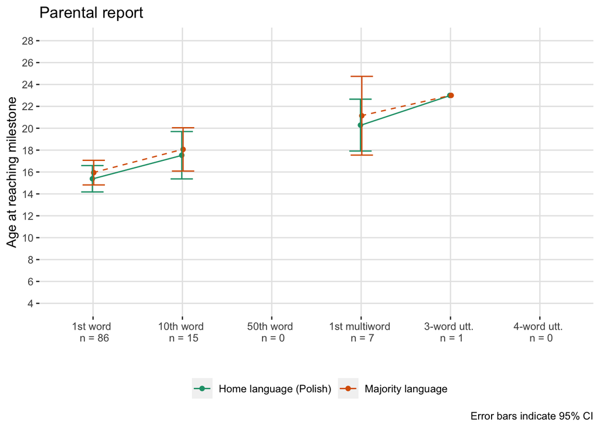

#### RQ2: t-test

```
## Levene's Test for Homogeneity of Variance (center = median)
##        Df F value Pr(>F)
## group   1    1.15   0.29
##       170
```

```
## Levene's Test for Homogeneity of Variance (center = median)
##       Df F value Pr(>F)
## group  1    0.35   0.56
##       28
```

| milestone | estimate | .y. | group1 | group2 | n1 | n2 | statistic | p | df | conf.low | conf.high | method | alternative | p.adj | p.adj.signif |
| --- | --- | --- | --- | --- | --- | --- | --- | --- | --- | --- | --- | --- | --- | --- | --- |
| w1 | -0.56 | age_at_element | HL | ML | 86 | 86 | -1.89 | 0.06 | 85 | -1.1 | 0.03 | T-test | two.sided | 0.12 | ns |
| w10 | -0.53 | age_at_element | HL | ML | 15 | 15 | -0.77 | 0.46 | 14 | -2.0 | 0.96 | T-test | two.sided | 0.46 | ns |

#### RQ2: Bayes Factors

#### Word1

```r
# w1
prebf_df <- rq2_w1
prepbf <-  lm(age_at_element~language_new-1, data=prebf_df)
coef(prepbf)
```

```
## language_newHL language_newML
##             15             16
```

```r
set.seed(100)
resbf<-bain(prepbf,"language_newHL = language_newML")
print(resbf)
```

```
## Bayesian informative hypothesis testing for an object of class lm (continuous predictors):
##
##    Fit   Com   BF.u   BF.c   PMPa  PMPb  PMPc
## H1 0.384 0.037 10.455 10.455 1.000 0.913 0.913
## Hu                                 0.087
## Hc                                       0.087
##
## Hypotheses:
##   H1: language_newHL=language_newML
##
## Note: BF.u denotes the Bayes factor of the hypothesis at hand versus the unconstrained hypothesis Hu. BF.c denotes the Bayes factor of the hypothesis at hand versus its complement. PMPa contains the posterior model probabilities of the hypotheses specified. PMPb adds Hu, the unconstrained hypothe…
```

```r
# Sensitivity Analysis
# compute BF01 using b-g (same BF as printed above)
resbf_sa<-bain(prepbf,"language_newHL = language_newML", fraction = 1)
print(resbf_sa)
```

```
## Bayesian informative hypothesis testing for an object of class lm (continuous predictors):
##
##    Fit   Com   BF.u   BF.c   PMPa  PMPb  PMPc
## H1 0.384 0.037 10.455 10.455 1.000 0.913 0.913
## Hu                                 0.087
## Hc                                       0.087
##
## Hypotheses:
##   H1: language_newHL=language_newML
##
## Note: BF.u denotes the Bayes factor of the hypothesis at hand versus the unconstrained hypothesis Hu. BF.c denotes the Bayes factor of the hypothesis at hand versus its complement. PMPa contains the posterior model probabilities of the hypotheses specified. PMPb adds Hu, the unconstrained hypothe…
```

```r
# compute BF01 replacing b-g by 2 x b-g
# setting fraction to 2 implies using 2 x b-g
set.seed(100)
resbf_sa<-bain(prepbf,"language_newHL = language_newML", fraction = 2)
print(resbf_sa)
```

```
## Bayesian informative hypothesis testing for an object of class lm (continuous predictors):
##
##    Fit   Com   BF.u  BF.c  PMPa  PMPb  PMPc
## H1 0.384 0.052 7.393 7.393 1.000 0.881 0.881
## Hu                               0.119
## Hc                                     0.119
##
## Hypotheses:
##   H1: language_newHL=language_newML
##
## Note: BF.u denotes the Bayes factor of the hypothesis at hand versus the unconstrained hypothesis Hu. BF.c denotes the Bayes factor of the hypothesis at hand versus its complement. PMPa contains the posterior model probabilities of the hypotheses specified. PMPb adds Hu, the unconstrained hypothe…
```

```r
# compute BF01 replacing b-g by 3 x b-g
set.seed(100)
resbf_sa<-bain(prepbf,"language_newHL = language_newML", fraction = 3)
print(resbf_sa)
```

```
## Bayesian informative hypothesis testing for an object of class lm (continuous predictors):
##
##    Fit   Com   BF.u  BF.c  PMPa  PMPb  PMPc
## H1 0.384 0.064 6.036 6.036 1.000 0.858 0.858
## Hu                               0.142
## Hc                                     0.142
##
## Hypotheses:
##   H1: language_newHL=language_newML
##
## Note: BF.u denotes the Bayes factor of the hypothesis at hand versus the unconstrained hypothesis Hu. BF.c denotes the Bayes factor of the hypothesis at hand versus its complement. PMPa contains the posterior model probabilities of the hypotheses specified. PMPb adds Hu, the unconstrained hypothe…
```

#### Word10

```r
# w10
prebf_df <- rq2_w10
prepbf <-  lm(age_at_element~language_new-1, data=prebf_df)
coef(prepbf)
```

```
## language_newHL language_newML
##             18             18
```

```r
set.seed(100)
resbf<-bain(prepbf,"language_newHL = language_newML")
print(resbf)
```

```
## Bayesian informative hypothesis testing for an object of class lm (continuous predictors):
##
##    Fit   Com   BF.u  BF.c  PMPa  PMPb  PMPc
## H1 0.270 0.053 5.076 5.076 1.000 0.835 0.835
## Hu                               0.165
## Hc                                     0.165
##
## Hypotheses:
##   H1: language_newHL=language_newML
##
## Note: BF.u denotes the Bayes factor of the hypothesis at hand versus the unconstrained hypothesis Hu. BF.c denotes the Bayes factor of the hypothesis at hand versus its complement. PMPa contains the posterior model probabilities of the hypotheses specified. PMPb adds Hu, the unconstrained hypothe…
```

```r
# Sensitivity Analysis
# compute BF01 using b-g (same BF as printed above)
set.seed(100)
resbf_sa<-bain(prepbf,"language_newHL = language_newML", fraction = 1)
print(resbf_sa)
```

```
## Bayesian informative hypothesis testing for an object of class lm (continuous predictors):
##
##    Fit   Com   BF.u  BF.c  PMPa  PMPb  PMPc
## H1 0.270 0.053 5.076 5.076 1.000 0.835 0.835
## Hu                               0.165
## Hc                                     0.165
##
## Hypotheses:
##   H1: language_newHL=language_newML
##
## Note: BF.u denotes the Bayes factor of the hypothesis at hand versus the unconstrained hypothesis Hu. BF.c denotes the Bayes factor of the hypothesis at hand versus its complement. PMPa contains the posterior model probabilities of the hypotheses specified. PMPb adds Hu, the unconstrained hypothe…
```

```r
# compute BF01 replacing b-g by 2 x b-g
set.seed(100)
# setting fraction to 2 implies using 2 x b-g
resbf_sa<-bain(prepbf,"language_newHL = language_newML", fraction = 2)
print(resbf_sa)
```

```
## Bayesian informative hypothesis testing for an object of class lm (continuous predictors):
##
##    Fit   Com   BF.u  BF.c  PMPa  PMPb  PMPc
## H1 0.270 0.075 3.589 3.589 1.000 0.782 0.782
## Hu                               0.218
## Hc                                     0.218
##
## Hypotheses:
##   H1: language_newHL=language_newML
##
## Note: BF.u denotes the Bayes factor of the hypothesis at hand versus the unconstrained hypothesis Hu. BF.c denotes the Bayes factor of the hypothesis at hand versus its complement. PMPa contains the posterior model probabilities of the hypotheses specified. PMPb adds Hu, the unconstrained hypothe…
```

```r
# compute BF01 replacing b-g by 3 x b-g
set.seed(100)
# setting fraction to 2 implies using 2 x b-g
resbf_sa<-bain(prepbf,"language_newHL = language_newML", fraction = 3)
print(resbf_sa)
```

```
## Bayesian informative hypothesis testing for an object of class lm (continuous predictors):
##
##    Fit   Com   BF.u  BF.c  PMPa  PMPb  PMPc
## H1 0.270 0.092 2.931 2.931 1.000 0.746 0.746
## Hu                               0.254
## Hc                                     0.254
##
## Hypotheses:
##   H1: language_newHL=language_newML
##
## Note: BF.u denotes the Bayes factor of the hypothesis at hand versus the unconstrained hypothesis Hu. BF.c denotes the Bayes factor of the hypothesis at hand versus its complement. PMPa contains the posterior model probabilities of the hypotheses specified. PMPb adds Hu, the unconstrained hypothe…
```

#### Multiword1

```r
# m1
prebf_df <- rq2_m1
prepbf <-  lm(age_at_element~language_new-1, data=prebf_df)
coef(prepbf)
```

```
## language_newHL language_newML
##             20             21
```

```r
set.seed(100)
resbf<-bain(prepbf,"language_newHL = language_newML")
print(resbf)
```

```
## Bayesian informative hypothesis testing for an object of class lm (continuous predictors):
##
##    Fit   Com   BF.u  BF.c  PMPa  PMPb  PMPc
## H1 0.201 0.061 3.324 3.324 1.000 0.769 0.769
## Hu                               0.231
## Hc                                     0.231
##
## Hypotheses:
##   H1: language_newHL=language_newML
##
## Note: BF.u denotes the Bayes factor of the hypothesis at hand versus the unconstrained hypothesis Hu. BF.c denotes the Bayes factor of the hypothesis at hand versus its complement. PMPa contains the posterior model probabilities of the hypotheses specified. PMPb adds Hu, the unconstrained hypothe…
```

```r
# Sensitivity Analysis
# compute BF01 using b-g (same BF as printed above)
set.seed(100)
resbf_sa<-bain(prepbf,"language_newHL = language_newML", fraction = 1)
print(resbf_sa)
```

```
## Bayesian informative hypothesis testing for an object of class lm (continuous predictors):
##
##    Fit   Com   BF.u  BF.c  PMPa  PMPb  PMPc
## H1 0.201 0.061 3.324 3.324 1.000 0.769 0.769
## Hu                               0.231
## Hc                                     0.231
##
## Hypotheses:
##   H1: language_newHL=language_newML
##
## Note: BF.u denotes the Bayes factor of the hypothesis at hand versus the unconstrained hypothesis Hu. BF.c denotes the Bayes factor of the hypothesis at hand versus its complement. PMPa contains the posterior model probabilities of the hypotheses specified. PMPb adds Hu, the unconstrained hypothe…
```

```r
# compute BF01 replacing b-g by 2 x b-g
set.seed(100)
# setting fraction to 2 implies using 2 x b-g
resbf_sa<-bain(prepbf,"language_newHL = language_newML", fraction = 2)
print(resbf_sa)
```

```
## Bayesian informative hypothesis testing for an object of class lm (continuous predictors):
##
##    Fit   Com   BF.u  BF.c  PMPa  PMPb  PMPc
## H1 0.201 0.086 2.350 2.350 1.000 0.702 0.702
## Hu                               0.298
## Hc                                     0.298
##
## Hypotheses:
##   H1: language_newHL=language_newML
##
## Note: BF.u denotes the Bayes factor of the hypothesis at hand versus the unconstrained hypothesis Hu. BF.c denotes the Bayes factor of the hypothesis at hand versus its complement. PMPa contains the posterior model probabilities of the hypotheses specified. PMPb adds Hu, the unconstrained hypothe…
```

```r
# compute BF01 replacing b-g by 3 x b-g
set.seed(100)
# setting fraction to 2 implies using 2 x b-g
resbf_sa<-bain(prepbf,"language_newHL = language_newML", fraction = 3)
print(resbf_sa)
```

```
## Bayesian informative hypothesis testing for an object of class lm (continuous predictors):
##
##    Fit   Com   BF.u  BF.c  PMPa  PMPb  PMPc
## H1 0.201 0.105 1.919 1.919 1.000 0.657 0.657
## Hu                               0.343
## Hc                                     0.343
##
## Hypotheses:
##   H1: language_newHL=language_newML
##
## Note: BF.u denotes the Bayes factor of the hypothesis at hand versus the unconstrained hypothesis Hu. BF.c denotes the Bayes factor of the hypothesis at hand versus its complement. PMPa contains the posterior model probabilities of the hypotheses specified. PMPb adds Hu, the unconstrained hypothe…
```

### Appendix A

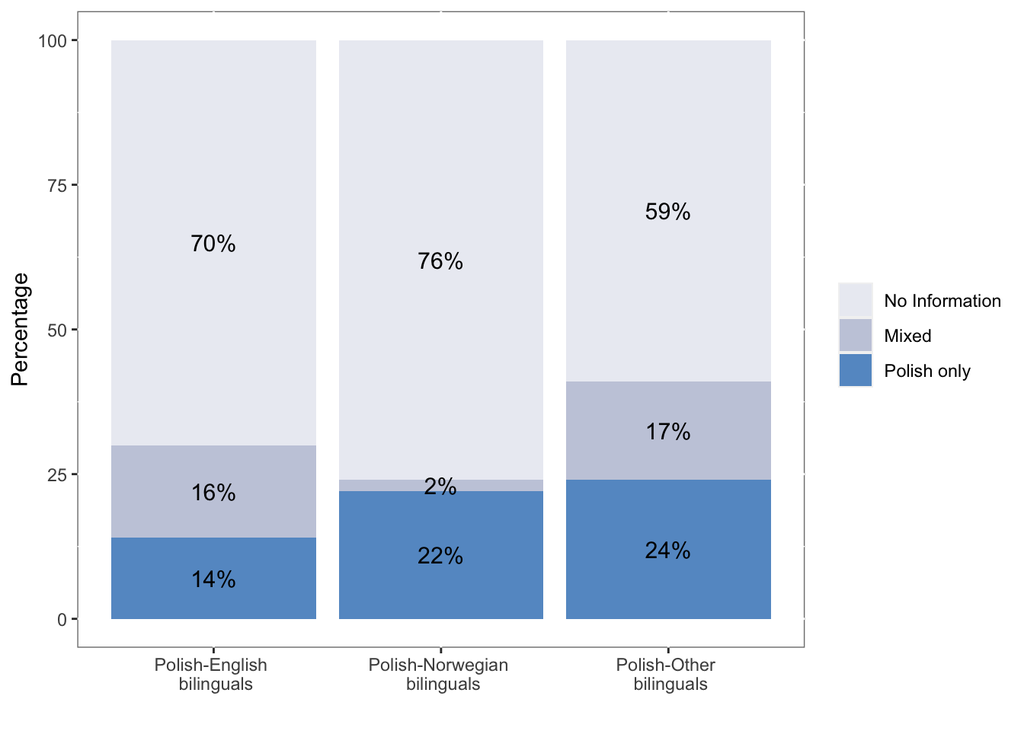

```
## Saving 2100 x 1400 px image
```

### Appendix B

Here we’re following the analyses for RQ1 (bilinguals vs. monolinguals) but for three groups: one group of bilingual children and TWO DISTINCT matched groups of monolingual children.

#### Figure B1

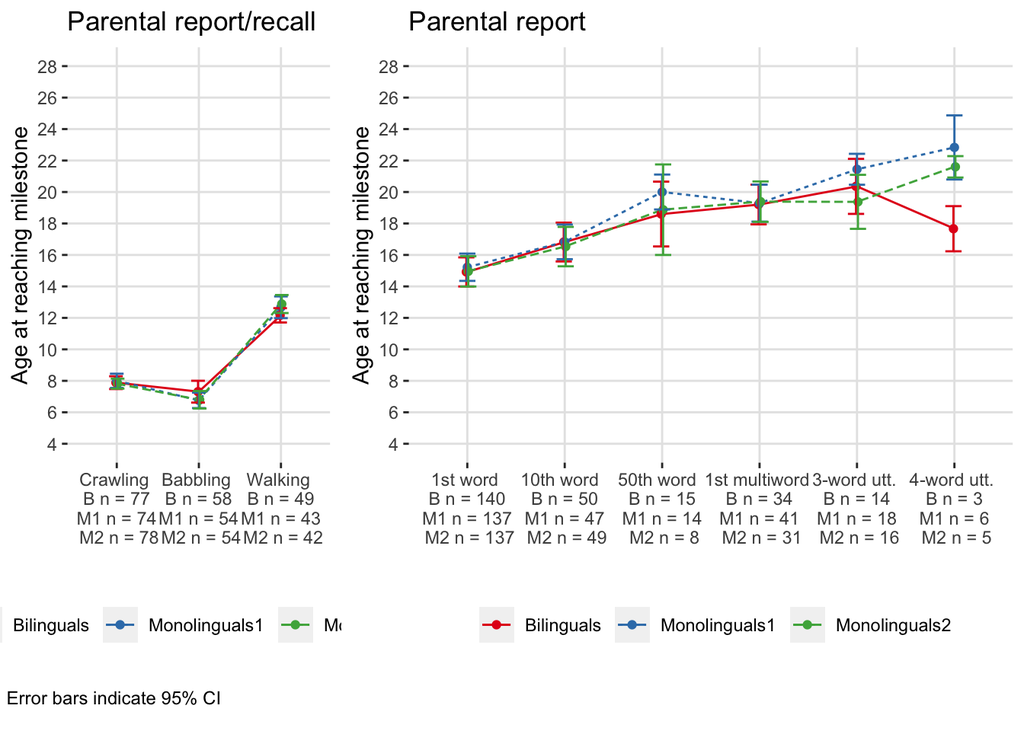

#### Table B3

| milestone | group | n | Age (M) | Age (SD) |
| --- | --- | --- | --- | --- |
| crawling_age | Bilinguals | 77 | 7.88 | 1.79 |
| crawling_age | Monolinguals1 | 74 | 8.00 | 1.95 |
| crawling_age | Monolinguals2 | 78 | 7.82 | 1.40 |
| babbling_age | Bilinguals | 58 | 7.31 | 2.64 |
| babbling_age | Monolinguals1 | 54 | 6.76 | 1.80 |
| babbling_age | Monolinguals2 | 54 | 6.80 | 2.03 |
| walking_age | Bilinguals | 49 | 12.16 | 1.59 |
| walking_age | Monolinguals1 | 43 | 12.67 | 2.24 |
| walking_age | Monolinguals2 | 42 | 12.88 | 1.84 |
| w1 | Bilinguals | 140 | 14.92 | 5.53 |
| w1 | Monolinguals1 | 137 | 15.22 | 5.13 |
| w1 | Monolinguals2 | 137 | 14.96 | 5.70 |
| w10 | Bilinguals | 50 | 16.82 | 4.34 |
| w10 | Monolinguals1 | 47 | 16.83 | 3.75 |
| w10 | Monolinguals2 | 49 | 16.53 | 4.36 |
| w50 | Bilinguals | 15 | 18.60 | 3.72 |
| w50 | Monolinguals1 | 14 | 20.00 | 1.92 |
| w50 | Monolinguals2 | 8 | 18.88 | 3.44 |
| m1 | Bilinguals | 34 | 19.21 | 3.62 |
| m1 | Monolinguals1 | 41 | 19.29 | 3.72 |
| m1 | Monolinguals2 | 31 | 19.39 | 3.50 |
| m3 | Bilinguals | 14 | 20.36 | 3.03 |
| m3 | Monolinguals1 | 18 | 21.44 | 1.98 |
| m3 | Monolinguals2 | 16 | 19.38 | 3.22 |
| m4 | Bilinguals | 3 | 17.67 | 0.58 |
| m4 | Monolinguals1 | 6 | 22.83 | 1.94 |
| m4 | Monolinguals2 | 5 | 21.60 | 0.55 |

#### Appendix B: one-way ANOVAs

##### Crawling

```
##              Df Sum Sq Mean Sq F value Pr(>F)
## group         2      1   0.627    0.21   0.81
## Residuals   226    673   2.980
## 676 observations deleted due to missingness
```

```
## # Effect Size for ANOVA (Type I)
##
## Parameter |     Eta2 |       95% CI
## -----------------------------------
## group     | 1.86e-03 | [0.00, 1.00]
##
## - One-sided CIs: upper bound fixed at [1.00].
```

##### Babbling

```
##              Df Sum Sq Mean Sq F value Pr(>F)
## group         2     11    5.37    1.11   0.33
## Residuals   163    787    4.83
## 734 observations deleted due to missingness
```

```
## # Effect Size for ANOVA (Type I)
##
## Parameter | Eta2 |       95% CI
## -------------------------------
## group     | 0.01 | [0.00, 1.00]
##
## - One-sided CIs: upper bound fixed at [1.00].
```

##### Walking

```
##              Df Sum Sq Mean Sq F value Pr(>F)
## group         2     13    6.30    1.75   0.18
## Residuals   131    471    3.59
## 772 observations deleted due to missingness
```

```
## # Effect Size for ANOVA (Type I)
##
## Parameter | Eta2 |       95% CI
## -------------------------------
## group     | 0.03 | [0.00, 1.00]
##
## - One-sided CIs: upper bound fixed at [1.00].
```

##### Word1

```
##              Df Sum Sq Mean Sq F value Pr(>F)
## group         2      7    3.64    0.12   0.89
## Residuals   411  12257   29.82
## 492 observations deleted due to missingness
```

```
## # Effect Size for ANOVA (Type I)
##
## Parameter |     Eta2 |       95% CI
## -----------------------------------
## group     | 5.94e-04 | [0.00, 1.00]
##
## - One-sided CIs: upper bound fixed at [1.00].
```

##### Word10

```
##              Df Sum Sq Mean Sq F value Pr(>F)
## group         2      3    1.41    0.08   0.92
## Residuals   143   2482   17.36
## 759 observations deleted due to missingness
```

##### Word50

```
##             Df Sum Sq Mean Sq F value Pr(>F)
## group        2     15    7.60     0.8   0.46
## Residuals   34    324    9.54
## 867 observations deleted due to missingness
```

##### Multiword1

```
##              Df Sum Sq Mean Sq F value Pr(>F)
## group         2      1    0.27    0.02   0.98
## Residuals   103   1353   13.14
## 800 observations deleted due to missingness
```

##### Multiword3

```
##             Df Sum Sq Mean Sq F value Pr(>F)
## group        2     36   18.20     2.4    0.1
## Residuals   45    341    7.59
## 855 observations deleted due to missingness
```

#### Appendix B: Bayes Factor

```r
lineplot_B <- lineplot_B_longer %>%
  pivot_wider(id_cols = c(child_anonim, group), names_from = milestone, values_from = age_at_element)

# Following Hoijtink, H., Mulder, J., Van Lissa, C., & Gu, X. (2019). A tutorial on testing hypotheses using the Bayes factor. Psychological Methods, 24(5), 539–556. https://doi.org/10.1037/met0000201
```

##### Crawling

```
##    groupBilinguals groupMonolinguals1 groupMonolinguals2
##                7.9                8.0                7.8
```

```
## Bayesian informative hypothesis testing for an object of class lm (continuous predictors):
##
##    Fit   Com   BF.u   BF.c   PMPa  PMPb  PMPc
## H1 1.906 0.021 92.762 92.762 1.000 0.989 0.989
## Hu                                 0.011
## Hc                                       0.011
##
## Hypotheses:
##   H1: groupBilinguals=groupMonolinguals1=groupMonolinguals2
##
## Note: BF.u denotes the Bayes factor of the hypothesis at hand versus the unconstrained hypothesis Hu. BF.c denotes the Bayes factor of the hypothesis at hand versus its complement. PMPa contains the posterior model probabilities of the hypotheses specified. PMPb adds Hu, the unconstrained hypothe…
```

```
## Bayesian informative hypothesis testing for an object of class lm (continuous predictors):
##
##    Fit   Com   BF.u   BF.c   PMPa  PMPb  PMPc
## H1 1.906 0.021 92.762 92.762 1.000 0.989 0.989
## Hu                                 0.011
## Hc                                       0.011
##
## Hypotheses:
##   H1: groupBilinguals=groupMonolinguals1=groupMonolinguals2
##
## Note: BF.u denotes the Bayes factor of the hypothesis at hand versus the unconstrained hypothesis Hu. BF.c denotes the Bayes factor of the hypothesis at hand versus its complement. PMPa contains the posterior model probabilities of the hypotheses specified. PMPb adds Hu, the unconstrained hypothe…
```

```
## Bayesian informative hypothesis testing for an object of class lm (continuous predictors):
##
##    Fit   Com   BF.u   BF.c   PMPa  PMPb  PMPc
## H1 1.906 0.041 46.381 46.381 1.000 0.979 0.979
## Hu                                 0.021
## Hc                                       0.021
##
## Hypotheses:
##   H1: groupBilinguals=groupMonolinguals1=groupMonolinguals2
##
## Note: BF.u denotes the Bayes factor of the hypothesis at hand versus the unconstrained hypothesis Hu. BF.c denotes the Bayes factor of the hypothesis at hand versus its complement. PMPa contains the posterior model probabilities of the hypotheses specified. PMPb adds Hu, the unconstrained hypothe…
```

```
## Bayesian informative hypothesis testing for an object of class lm (continuous predictors):
##
##    Fit   Com   BF.u   BF.c   PMPa  PMPb  PMPc
## H1 1.906 0.062 30.921 30.921 1.000 0.969 0.969
## Hu                                 0.031
## Hc                                       0.031
##
## Hypotheses:
##   H1: groupBilinguals=groupMonolinguals1=groupMonolinguals2
##
## Note: BF.u denotes the Bayes factor of the hypothesis at hand versus the unconstrained hypothesis Hu. BF.c denotes the Bayes factor of the hypothesis at hand versus its complement. PMPa contains the posterior model probabilities of the hypotheses specified. PMPb adds Hu, the unconstrained hypothe…
```

##### Babbling

```
##    groupBilinguals groupMonolinguals1 groupMonolinguals2
##                7.3                6.8                6.8
```

```
## Bayesian informative hypothesis testing for an object of class lm (continuous predictors):
##
##    Fit   Com   BF.u   BF.c   PMPa  PMPb  PMPc
## H1 0.346 0.013 27.295 27.295 1.000 0.965 0.965
## Hu                                 0.035
## Hc                                       0.035
##
## Hypotheses:
##   H1: groupBilinguals=groupMonolinguals1=groupMonolinguals2
##
## Note: BF.u denotes the Bayes factor of the hypothesis at hand versus the unconstrained hypothesis Hu. BF.c denotes the Bayes factor of the hypothesis at hand versus its complement. PMPa contains the posterior model probabilities of the hypotheses specified. PMPb adds Hu, the unconstrained hypothe…
```

```
## Bayesian informative hypothesis testing for an object of class lm (continuous predictors):
##
##    Fit   Com   BF.u   BF.c   PMPa  PMPb  PMPc
## H1 0.346 0.013 27.295 27.295 1.000 0.965 0.965
## Hu                                 0.035
## Hc                                       0.035
##
## Hypotheses:
##   H1: groupBilinguals=groupMonolinguals1=groupMonolinguals2
##
## Note: BF.u denotes the Bayes factor of the hypothesis at hand versus the unconstrained hypothesis Hu. BF.c denotes the Bayes factor of the hypothesis at hand versus its complement. PMPa contains the posterior model probabilities of the hypotheses specified. PMPb adds Hu, the unconstrained hypothe…
```

```
## Bayesian informative hypothesis testing for an object of class lm (continuous predictors):
##
##    Fit   Com   BF.u   BF.c   PMPa  PMPb  PMPc
## H1 0.346 0.025 13.648 13.648 1.000 0.932 0.932
## Hu                                 0.068
## Hc                                       0.068
##
## Hypotheses:
##   H1: groupBilinguals=groupMonolinguals1=groupMonolinguals2
##
## Note: BF.u denotes the Bayes factor of the hypothesis at hand versus the unconstrained hypothesis Hu. BF.c denotes the Bayes factor of the hypothesis at hand versus its complement. PMPa contains the posterior model probabilities of the hypotheses specified. PMPb adds Hu, the unconstrained hypothe…
```

```
## Bayesian informative hypothesis testing for an object of class lm (continuous predictors):
##
##    Fit   Com   BF.u  BF.c  PMPa  PMPb  PMPc
## H1 0.346 0.038 9.098 9.098 1.000 0.901 0.901
## Hu                               0.099
## Hc                                     0.099
##
## Hypotheses:
##   H1: groupBilinguals=groupMonolinguals1=groupMonolinguals2
##
## Note: BF.u denotes the Bayes factor of the hypothesis at hand versus the unconstrained hypothesis Hu. BF.c denotes the Bayes factor of the hypothesis at hand versus its complement. PMPa contains the posterior model probabilities of the hypotheses specified. PMPb adds Hu, the unconstrained hypothe…
```

##### Walking

```
##    groupBilinguals groupMonolinguals1 groupMonolinguals2
##                 12                 13                 13
```

```
## Bayesian informative hypothesis testing for an object of class lm (continuous predictors):
##
##    Fit   Com   BF.u   BF.c   PMPa  PMPb  PMPc
## H1 0.197 0.017 11.607 11.607 1.000 0.921 0.921
## Hu                                 0.079
## Hc                                       0.079
##
## Hypotheses:
##   H1: groupBilinguals=groupMonolinguals1=groupMonolinguals2
##
## Note: BF.u denotes the Bayes factor of the hypothesis at hand versus the unconstrained hypothesis Hu. BF.c denotes the Bayes factor of the hypothesis at hand versus its complement. PMPa contains the posterior model probabilities of the hypotheses specified. PMPb adds Hu, the unconstrained hypothe…
```

```
## Bayesian informative hypothesis testing for an object of class lm (continuous predictors):
##
##    Fit   Com   BF.u   BF.c   PMPa  PMPb  PMPc
## H1 0.197 0.017 11.607 11.607 1.000 0.921 0.921
## Hu                                 0.079
## Hc                                       0.079
##
## Hypotheses:
##   H1: groupBilinguals=groupMonolinguals1=groupMonolinguals2
##
## Note: BF.u denotes the Bayes factor of the hypothesis at hand versus the unconstrained hypothesis Hu. BF.c denotes the Bayes factor of the hypothesis at hand versus its complement. PMPa contains the posterior model probabilities of the hypotheses specified. PMPb adds Hu, the unconstrained hypothe…
```

```
## Bayesian informative hypothesis testing for an object of class lm (continuous predictors):
##
##    Fit   Com   BF.u  BF.c  PMPa  PMPb  PMPc
## H1 0.197 0.034 5.804 5.804 1.000 0.853 0.853
## Hu                               0.147
## Hc                                     0.147
##
## Hypotheses:
##   H1: groupBilinguals=groupMonolinguals1=groupMonolinguals2
##
## Note: BF.u denotes the Bayes factor of the hypothesis at hand versus the unconstrained hypothesis Hu. BF.c denotes the Bayes factor of the hypothesis at hand versus its complement. PMPa contains the posterior model probabilities of the hypotheses specified. PMPb adds Hu, the unconstrained hypothe…
```

```
## Bayesian informative hypothesis testing for an object of class lm (continuous predictors):
##
##    Fit   Com   BF.u  BF.c  PMPa  PMPb  PMPc
## H1 0.197 0.051 3.869 3.869 1.000 0.795 0.795
## Hu                               0.205
## Hc                                     0.205
##
## Hypotheses:
##   H1: groupBilinguals=groupMonolinguals1=groupMonolinguals2
##
## Note: BF.u denotes the Bayes factor of the hypothesis at hand versus the unconstrained hypothesis Hu. BF.c denotes the Bayes factor of the hypothesis at hand versus its complement. PMPa contains the posterior model probabilities of the hypotheses specified. PMPb adds Hu, the unconstrained hypothe…
```

##### Word1

```
##    groupBilinguals groupMonolinguals1 groupMonolinguals2
##                 15                 15                 15
```

```
## Bayesian informative hypothesis testing for an object of class lm (continuous predictors):
##
##    Fit   Com   BF.u    BF.c    PMPa  PMPb  PMPc
## H1 0.376 0.002 183.191 183.191 1.000 0.995 0.995
## Hu                                   0.005
## Hc                                         0.005
##
## Hypotheses:
##   H1: groupBilinguals=groupMonolinguals1=groupMonolinguals2
##
## Note: BF.u denotes the Bayes factor of the hypothesis at hand versus the unconstrained hypothesis Hu. BF.c denotes the Bayes factor of the hypothesis at hand versus its complement. PMPa contains the posterior model probabilities of the hypotheses specified. PMPb adds Hu, the unconstrained hypothe…
```

```
## Bayesian informative hypothesis testing for an object of class lm (continuous predictors):
##
##    Fit   Com   BF.u    BF.c    PMPa  PMPb  PMPc
## H1 0.376 0.002 183.191 183.191 1.000 0.995 0.995
## Hu                                   0.005
## Hc                                         0.005
##
## Hypotheses:
##   H1: groupBilinguals=groupMonolinguals1=groupMonolinguals2
##
## Note: BF.u denotes the Bayes factor of the hypothesis at hand versus the unconstrained hypothesis Hu. BF.c denotes the Bayes factor of the hypothesis at hand versus its complement. PMPa contains the posterior model probabilities of the hypotheses specified. PMPb adds Hu, the unconstrained hypothe…
```

```
## Bayesian informative hypothesis testing for an object of class lm (continuous predictors):
##
##    Fit   Com   BF.u   BF.c   PMPa  PMPb  PMPc
## H1 0.376 0.004 91.595 91.595 1.000 0.989 0.989
## Hu                                 0.011
## Hc                                       0.011
##
## Hypotheses:
##   H1: groupBilinguals=groupMonolinguals1=groupMonolinguals2
##
## Note: BF.u denotes the Bayes factor of the hypothesis at hand versus the unconstrained hypothesis Hu. BF.c denotes the Bayes factor of the hypothesis at hand versus its complement. PMPa contains the posterior model probabilities of the hypotheses specified. PMPb adds Hu, the unconstrained hypothe…
```

```
## Bayesian informative hypothesis testing for an object of class lm (continuous predictors):
##
##    Fit   Com   BF.u   BF.c   PMPa  PMPb  PMPc
## H1 0.376 0.006 61.064 61.064 1.000 0.984 0.984
## Hu                                 0.016
## Hc                                       0.016
##
## Hypotheses:
##   H1: groupBilinguals=groupMonolinguals1=groupMonolinguals2
##
## Note: BF.u denotes the Bayes factor of the hypothesis at hand versus the unconstrained hypothesis Hu. BF.c denotes the Bayes factor of the hypothesis at hand versus its complement. PMPa contains the posterior model probabilities of the hypotheses specified. PMPb adds Hu, the unconstrained hypothe…
```

##### Word10

```
##    groupBilinguals groupMonolinguals1 groupMonolinguals2
##                 17                 17                 17
```

```
## Bayesian informative hypothesis testing for an object of class lm (continuous predictors):
##
##    Fit   Com   BF.u   BF.c   PMPa  PMPb  PMPc
## H1 0.237 0.004 67.307 67.307 1.000 0.985 0.985
## Hu                                 0.015
## Hc                                       0.015
##
## Hypotheses:
##   H1: groupBilinguals=groupMonolinguals1=groupMonolinguals2
##
## Note: BF.u denotes the Bayes factor of the hypothesis at hand versus the unconstrained hypothesis Hu. BF.c denotes the Bayes factor of the hypothesis at hand versus its complement. PMPa contains the posterior model probabilities of the hypotheses specified. PMPb adds Hu, the unconstrained hypothe…
```

```
## Bayesian informative hypothesis testing for an object of class lm (continuous predictors):
##
##    Fit   Com   BF.u   BF.c   PMPa  PMPb  PMPc
## H1 0.237 0.004 67.307 67.307 1.000 0.985 0.985
## Hu                                 0.015
## Hc                                       0.015
##
## Hypotheses:
##   H1: groupBilinguals=groupMonolinguals1=groupMonolinguals2
##
## Note: BF.u denotes the Bayes factor of the hypothesis at hand versus the unconstrained hypothesis Hu. BF.c denotes the Bayes factor of the hypothesis at hand versus its complement. PMPa contains the posterior model probabilities of the hypotheses specified. PMPb adds Hu, the unconstrained hypothe…
```

```
## Bayesian informative hypothesis testing for an object of class lm (continuous predictors):
##
##    Fit   Com   BF.u   BF.c   PMPa  PMPb  PMPc
## H1 0.237 0.007 33.654 33.654 1.000 0.971 0.971
## Hu                                 0.029
## Hc                                       0.029
##
## Hypotheses:
##   H1: groupBilinguals=groupMonolinguals1=groupMonolinguals2
##
## Note: BF.u denotes the Bayes factor of the hypothesis at hand versus the unconstrained hypothesis Hu. BF.c denotes the Bayes factor of the hypothesis at hand versus its complement. PMPa contains the posterior model probabilities of the hypotheses specified. PMPb adds Hu, the unconstrained hypothe…
```

```
## Bayesian informative hypothesis testing for an object of class lm (continuous predictors):
##
##    Fit   Com   BF.u   BF.c   PMPa  PMPb  PMPc
## H1 0.237 0.011 22.436 22.436 1.000 0.957 0.957
## Hu                                 0.043
## Hc                                       0.043
##
## Hypotheses:
##   H1: groupBilinguals=groupMonolinguals1=groupMonolinguals2
##
## Note: BF.u denotes the Bayes factor of the hypothesis at hand versus the unconstrained hypothesis Hu. BF.c denotes the Bayes factor of the hypothesis at hand versus its complement. PMPa contains the posterior model probabilities of the hypotheses specified. PMPb adds Hu, the unconstrained hypothe…
```

##### Word50

```
##    groupBilinguals groupMonolinguals1 groupMonolinguals2
##                 19                 20                 19
```

```
## Bayesian informative hypothesis testing for an object of class lm (continuous predictors):
##
##    Fit   Com   BF.u  BF.c  PMPa  PMPb  PMPc
## H1 0.051 0.006 8.343 8.343 1.000 0.893 0.893
## Hu                               0.107
## Hc                                     0.107
##
## Hypotheses:
##   H1: groupBilinguals=groupMonolinguals1=groupMonolinguals2
##
## Note: BF.u denotes the Bayes factor of the hypothesis at hand versus the unconstrained hypothesis Hu. BF.c denotes the Bayes factor of the hypothesis at hand versus its complement. PMPa contains the posterior model probabilities of the hypotheses specified. PMPb adds Hu, the unconstrained hypothe…
```

```
## Bayesian informative hypothesis testing for an object of class lm (continuous predictors):
##
##    Fit   Com   BF.u  BF.c  PMPa  PMPb  PMPc
## H1 0.051 0.006 8.343 8.343 1.000 0.893 0.893
## Hu                               0.107
## Hc                                     0.107
##
## Hypotheses:
##   H1: groupBilinguals=groupMonolinguals1=groupMonolinguals2
##
## Note: BF.u denotes the Bayes factor of the hypothesis at hand versus the unconstrained hypothesis Hu. BF.c denotes the Bayes factor of the hypothesis at hand versus its complement. PMPa contains the posterior model probabilities of the hypotheses specified. PMPb adds Hu, the unconstrained hypothe…
```

```
## Bayesian informative hypothesis testing for an object of class lm (continuous predictors):
##
##    Fit   Com   BF.u  BF.c  PMPa  PMPb  PMPc
## H1 0.051 0.012 4.171 4.171 1.000 0.807 0.807
## Hu                               0.193
## Hc                                     0.193
##
## Hypotheses:
##   H1: groupBilinguals=groupMonolinguals1=groupMonolinguals2
##
## Note: BF.u denotes the Bayes factor of the hypothesis at hand versus the unconstrained hypothesis Hu. BF.c denotes the Bayes factor of the hypothesis at hand versus its complement. PMPa contains the posterior model probabilities of the hypotheses specified. PMPb adds Hu, the unconstrained hypothe…
```

```
## Bayesian informative hypothesis testing for an object of class lm (continuous predictors):
##
##    Fit   Com   BF.u  BF.c  PMPa  PMPb  PMPc
## H1 0.051 0.018 2.781 2.781 1.000 0.736 0.736
## Hu                               0.264
## Hc                                     0.264
##
## Hypotheses:
##   H1: groupBilinguals=groupMonolinguals1=groupMonolinguals2
##
## Note: BF.u denotes the Bayes factor of the hypothesis at hand versus the unconstrained hypothesis Hu. BF.c denotes the Bayes factor of the hypothesis at hand versus its complement. PMPa contains the posterior model probabilities of the hypotheses specified. PMPb adds Hu, the unconstrained hypothe…
```

##### Multiword1

```
##    groupBilinguals groupMonolinguals1 groupMonolinguals2
##                 19                 19                 19
```

```
## Bayesian informative hypothesis testing for an object of class lm (continuous predictors):
##
##    Fit   Com   BF.u   BF.c   PMPa  PMPb  PMPc
## H1 0.240 0.005 51.937 51.937 1.000 0.981 0.981
## Hu                                 0.019
## Hc                                       0.019
##
## Hypotheses:
##   H1: groupBilinguals=groupMonolinguals1=groupMonolinguals2
##
## Note: BF.u denotes the Bayes factor of the hypothesis at hand versus the unconstrained hypothesis Hu. BF.c denotes the Bayes factor of the hypothesis at hand versus its complement. PMPa contains the posterior model probabilities of the hypotheses specified. PMPb adds Hu, the unconstrained hypothe…
```

```
## Bayesian informative hypothesis testing for an object of class lm (continuous predictors):
##
##    Fit   Com   BF.u   BF.c   PMPa  PMPb  PMPc
## H1 0.240 0.005 51.937 51.937 1.000 0.981 0.981
## Hu                                 0.019
## Hc                                       0.019
##
## Hypotheses:
##   H1: groupBilinguals=groupMonolinguals1=groupMonolinguals2
##
## Note: BF.u denotes the Bayes factor of the hypothesis at hand versus the unconstrained hypothesis Hu. BF.c denotes the Bayes factor of the hypothesis at hand versus its complement. PMPa contains the posterior model probabilities of the hypotheses specified. PMPb adds Hu, the unconstrained hypothe…
```

```
## Bayesian informative hypothesis testing for an object of class lm (continuous predictors):
##
##    Fit   Com   BF.u   BF.c   PMPa  PMPb  PMPc
## H1 0.240 0.009 25.968 25.968 1.000 0.963 0.963
## Hu                                 0.037
## Hc                                       0.037
##
## Hypotheses:
##   H1: groupBilinguals=groupMonolinguals1=groupMonolinguals2
##
## Note: BF.u denotes the Bayes factor of the hypothesis at hand versus the unconstrained hypothesis Hu. BF.c denotes the Bayes factor of the hypothesis at hand versus its complement. PMPa contains the posterior model probabilities of the hypotheses specified. PMPb adds Hu, the unconstrained hypothe…
```

```
## Bayesian informative hypothesis testing for an object of class lm (continuous predictors):
##
##    Fit   Com   BF.u   BF.c   PMPa  PMPb  PMPc
## H1 0.240 0.014 17.312 17.312 1.000 0.945 0.945
## Hu                                 0.055
## Hc                                       0.055
##
## Hypotheses:
##   H1: groupBilinguals=groupMonolinguals1=groupMonolinguals2
##
## Note: BF.u denotes the Bayes factor of the hypothesis at hand versus the unconstrained hypothesis Hu. BF.c denotes the Bayes factor of the hypothesis at hand versus its complement. PMPa contains the posterior model probabilities of the hypotheses specified. PMPb adds Hu, the unconstrained hypothe…
```

##### Multiword3

```
##    groupBilinguals groupMonolinguals1 groupMonolinguals2
##                 20                 21                 19
```

```
## Bayesian informative hypothesis testing for an object of class lm (continuous predictors):
##
##    Fit   Com   BF.u  BF.c  PMPa  PMPb  PMPc
## H1 0.017 0.008 2.179 2.179 1.000 0.685 0.685
## Hu                               0.315
## Hc                                     0.315
##
## Hypotheses:
##   H1: groupBilinguals=groupMonolinguals1=groupMonolinguals2
##
## Note: BF.u denotes the Bayes factor of the hypothesis at hand versus the unconstrained hypothesis Hu. BF.c denotes the Bayes factor of the hypothesis at hand versus its complement. PMPa contains the posterior model probabilities of the hypotheses specified. PMPb adds Hu, the unconstrained hypothe…
```

```
## Bayesian informative hypothesis testing for an object of class lm (continuous predictors):
##
##    Fit   Com   BF.u  BF.c  PMPa  PMPb  PMPc
## H1 0.017 0.008 2.179 2.179 1.000 0.685 0.685
## Hu                               0.315
## Hc                                     0.315
##
## Hypotheses:
##   H1: groupBilinguals=groupMonolinguals1=groupMonolinguals2
##
## Note: BF.u denotes the Bayes factor of the hypothesis at hand versus the unconstrained hypothesis Hu. BF.c denotes the Bayes factor of the hypothesis at hand versus its complement. PMPa contains the posterior model probabilities of the hypotheses specified. PMPb adds Hu, the unconstrained hypothe…
```

```
## Bayesian informative hypothesis testing for an object of class lm (continuous predictors):
##
##    Fit   Com   BF.u  BF.c  PMPa  PMPb  PMPc
## H1 0.017 0.016 1.090 1.090 1.000 0.521 0.521
## Hu                               0.479
## Hc                                     0.479
##
## Hypotheses:
##   H1: groupBilinguals=groupMonolinguals1=groupMonolinguals2
##
## Note: BF.u denotes the Bayes factor of the hypothesis at hand versus the unconstrained hypothesis Hu. BF.c denotes the Bayes factor of the hypothesis at hand versus its complement. PMPa contains the posterior model probabilities of the hypotheses specified. PMPb adds Hu, the unconstrained hypothe…
```

```
## Bayesian informative hypothesis testing for an object of class lm (continuous predictors):
##
##    Fit   Com   BF.u  BF.c  PMPa  PMPb  PMPc
## H1 0.017 0.024 0.726 0.726 1.000 0.421 0.421
## Hu                               0.579
## Hc                                     0.579
##
## Hypotheses:
##   H1: groupBilinguals=groupMonolinguals1=groupMonolinguals2
##
## Note: BF.u denotes the Bayes factor of the hypothesis at hand versus the unconstrained hypothesis Hu. BF.c denotes the Bayes factor of the hypothesis at hand versus its complement. PMPa contains the posterior model probabilities of the hypotheses specified. PMPb adds Hu, the unconstrained hypothe…
```

### Appendix C

Bilinguals from the UK and Norway

#### Polish-English bilinguals in the UK

```
## tibble [76 × 6] (S3: tbl_df/tbl/data.frame)
##  $ child_anonim: int [1:76] 120 120 146 146 176 176 187 187 243 243 ...
##  $ country     : chr [1:76] "NORWAY" "NORWAY" "UK" "UK" ...
##  $ language_new: chr [1:76] "HL" "ML" "HL" "ML" ...
##  $ w1          : int [1:76] 14 14 6 7 9 9 20 20 21 18 ...
##  $ w10         : int [1:76] 18 21 NA NA NA NA NA NA NA NA ...
##  $ m1          : int [1:76] NA NA NA NA NA NA NA NA 21 23 ...
```

| country | language_new | w1 n | w1 Age (M) | w1 Age (SD) | w10 n | w10 Age (M) | w10 Age (SD) | m1 n | m1 Age (M) | m1 Age (SD) |
| --- | --- | --- | --- | --- | --- | --- | --- | --- | --- | --- |
| NORWAY | HL | 11 | 14.91 | 4.83 | 2 | 16.50 | 2.12 | 0 | NaN | NA |
| NORWAY | ML | 11 | 15.82 | 4.81 | 2 | 18.00 | 4.24 | 0 | NaN | NA |
| UK | HL | 27 | 15.70 | 6.62 | 3 | 19.00 | 3.61 | 2 | 19.00 | 2.83 |
| UK | ML | 27 | 15.85 | 6.32 | 3 | 20.00 | 4.36 | 2 | 20.50 | 3.54 |

##### Word1

```r
reg_w1 %>%
  filter(country == "UK") %>%
  rstatix::t_test(age_at_element ~ language_new, paired = T, var.equal = T, conf.level = 0.95, detailed = T) %>%
  kable("html") %>% kable_styling()
```

| estimate | .y. | group1 | group2 | n1 | n2 | statistic | p | df | conf.low | conf.high | method | alternative |
| --- | --- | --- | --- | --- | --- | --- | --- | --- | --- | --- | --- | --- |
| -0.15 | age_at_element | HL | ML | 27 | 27 | -0.52 | 0.61 | 26 | -0.74 | 0.44 | T-test | two.sided |

```r
# w1
prebf_df <- reg_w1 %>% filter(country == "UK")
prepbf <-  lm(age_at_element~language_new-1, data=prebf_df)
coef(prepbf)
```

```
## language_newHL language_newML
##             16             16
```

```r
set.seed(100)
resbf<-bain(prepbf,"language_newHL = language_newML")
print(resbf)
```

```
## Bayesian informative hypothesis testing for an object of class lm (continuous predictors):
##
##    Fit   Com   BF.u  BF.c  PMPa  PMPb  PMPc
## H1 0.226 0.031 7.323 7.323 1.000 0.880 0.880
## Hu                               0.120
## Hc                                     0.120
##
## Hypotheses:
##   H1: language_newHL=language_newML
##
## Note: BF.u denotes the Bayes factor of the hypothesis at hand versus the unconstrained hypothesis Hu. BF.c denotes the Bayes factor of the hypothesis at hand versus its complement. PMPa contains the posterior model probabilities of the hypotheses specified. PMPb adds Hu, the unconstrained hypothe…
```

```r
# Sensitivity Analysis
# compute BF01 using b-g (same BF as printed above)
resbf_sa<-bain(prepbf,"language_newHL = language_newML", fraction = 1)
print(resbf_sa)
```

```
## Bayesian informative hypothesis testing for an object of class lm (continuous predictors):
##
##    Fit   Com   BF.u  BF.c  PMPa  PMPb  PMPc
## H1 0.226 0.031 7.323 7.323 1.000 0.880 0.880
## Hu                               0.120
## Hc                                     0.120
##
## Hypotheses:
##   H1: language_newHL=language_newML
##
## Note: BF.u denotes the Bayes factor of the hypothesis at hand versus the unconstrained hypothesis Hu. BF.c denotes the Bayes factor of the hypothesis at hand versus its complement. PMPa contains the posterior model probabilities of the hypotheses specified. PMPb adds Hu, the unconstrained hypothe…
```

```r
# compute BF01 replacing b-g by 2 x b-g
# setting fraction to 2 implies using 2 x b-g
set.seed(100)
resbf_sa<-bain(prepbf,"language_newHL = language_newML", fraction = 2)
print(resbf_sa)
```

```
## Bayesian informative hypothesis testing for an object of class lm (continuous predictors):
##
##    Fit   Com   BF.u  BF.c  PMPa  PMPb  PMPc
## H1 0.226 0.044 5.178 5.178 1.000 0.838 0.838
## Hu                               0.162
## Hc                                     0.162
##
## Hypotheses:
##   H1: language_newHL=language_newML
##
## Note: BF.u denotes the Bayes factor of the hypothesis at hand versus the unconstrained hypothesis Hu. BF.c denotes the Bayes factor of the hypothesis at hand versus its complement. PMPa contains the posterior model probabilities of the hypotheses specified. PMPb adds Hu, the unconstrained hypothe…
```

```r
# compute BF01 replacing b-g by 3 x b-g
set.seed(100)
resbf_sa<-bain(prepbf,"language_newHL = language_newML", fraction = 3)
print(resbf_sa)
```

```
## Bayesian informative hypothesis testing for an object of class lm (continuous predictors):
##
##    Fit   Com   BF.u  BF.c  PMPa  PMPb  PMPc
## H1 0.226 0.053 4.228 4.228 1.000 0.809 0.809
## Hu                               0.191
## Hc                                     0.191
##
## Hypotheses:
##   H1: language_newHL=language_newML
##
## Note: BF.u denotes the Bayes factor of the hypothesis at hand versus the unconstrained hypothesis Hu. BF.c denotes the Bayes factor of the hypothesis at hand versus its complement. PMPa contains the posterior model probabilities of the hypotheses specified. PMPb adds Hu, the unconstrained hypothe…
```

#### Polish-Norwegian bilinguals in Norway

##### Word1

```r
reg_w1 %>%
  filter(country == "NORWAY") %>%
  rstatix::t_test(age_at_element ~ language_new, paired = T, var.equal = T, conf.level = 0.95, detailed = T) %>%
  kable("html") %>% kable_styling()
```

| estimate | .y. | group1 | group2 | n1 | n2 | statistic | p | df | conf.low | conf.high | method | alternative |
| --- | --- | --- | --- | --- | --- | --- | --- | --- | --- | --- | --- | --- |
| -0.91 | age_at_element | HL | ML | 11 | 11 | -1.4 | 0.18 | 10 | -2.3 | 0.51 | T-test | two.sided |

```r
# w1
prebf_df <- reg_w1 %>% filter(country == "NORWAY")
prepbf <-  lm(age_at_element~language_new-1, data=prebf_df)
coef(prepbf)
```

```
## language_newHL language_newML
##             15             16
```

```r
set.seed(100)
resbf<-bain(prepbf,"language_newHL = language_newML")
print(resbf)
```

```
## Bayesian informative hypothesis testing for an object of class lm (continuous predictors):
##
##    Fit   Com   BF.u  BF.c  PMPa  PMPb  PMPc
## H1 0.176 0.041 4.253 4.253 1.000 0.810 0.810
## Hu                               0.190
## Hc                                     0.190
##
## Hypotheses:
##   H1: language_newHL=language_newML
##
## Note: BF.u denotes the Bayes factor of the hypothesis at hand versus the unconstrained hypothesis Hu. BF.c denotes the Bayes factor of the hypothesis at hand versus its complement. PMPa contains the posterior model probabilities of the hypotheses specified. PMPb adds Hu, the unconstrained hypothe…
```

```r
# Sensitivity Analysis
# compute BF01 using b-g (same BF as printed above)
resbf_sa<-bain(prepbf,"language_newHL = language_newML", fraction = 1)
print(resbf_sa)
```

```
## Bayesian informative hypothesis testing for an object of class lm (continuous predictors):
##
##    Fit   Com   BF.u  BF.c  PMPa  PMPb  PMPc
## H1 0.176 0.041 4.253 4.253 1.000 0.810 0.810
## Hu                               0.190
## Hc                                     0.190
##
## Hypotheses:
##   H1: language_newHL=language_newML
##
## Note: BF.u denotes the Bayes factor of the hypothesis at hand versus the unconstrained hypothesis Hu. BF.c denotes the Bayes factor of the hypothesis at hand versus its complement. PMPa contains the posterior model probabilities of the hypotheses specified. PMPb adds Hu, the unconstrained hypothe…
```

```r
# compute BF01 replacing b-g by 2 x b-g
# setting fraction to 2 implies using 2 x b-g
set.seed(100)
resbf_sa<-bain(prepbf,"language_newHL = language_newML", fraction = 2)
print(resbf_sa)
```

```
## Bayesian informative hypothesis testing for an object of class lm (continuous predictors):
##
##    Fit   Com   BF.u  BF.c  PMPa  PMPb  PMPc
## H1 0.176 0.059 3.007 3.007 1.000 0.750 0.750
## Hu                               0.250
## Hc                                     0.250
##
## Hypotheses:
##   H1: language_newHL=language_newML
##
## Note: BF.u denotes the Bayes factor of the hypothesis at hand versus the unconstrained hypothesis Hu. BF.c denotes the Bayes factor of the hypothesis at hand versus its complement. PMPa contains the posterior model probabilities of the hypotheses specified. PMPb adds Hu, the unconstrained hypothe…
```

```r
# compute BF01 replacing b-g by 3 x b-g
set.seed(100)
resbf_sa<-bain(prepbf,"language_newHL = language_newML", fraction = 3)
print(resbf_sa)
```

```
## Bayesian informative hypothesis testing for an object of class lm (continuous predictors):
##
##    Fit   Com   BF.u  BF.c  PMPa  PMPb  PMPc
## H1 0.176 0.072 2.456 2.456 1.000 0.711 0.711
## Hu                               0.289
## Hc                                     0.289
##
## Hypotheses:
##   H1: language_newHL=language_newML
##
## Note: BF.u denotes the Bayes factor of the hypothesis at hand versus the unconstrained hypothesis Hu. BF.c denotes the Bayes factor of the hypothesis at hand versus its complement. PMPa contains the posterior model probabilities of the hypotheses specified. PMPb adds Hu, the unconstrained hypothe…
```